# S-109A Introduction to Data Science:

[figure not shown]

## Homework 5: Logistic Regression, High Dimensionality and PCA, LDA/QDA

**Harvard University**  
**Summer 2018**  
**Instructors**: Pavlos Protopapas, Kevin Rader

### INSTRUCTIONS

- To submit your assignment follow the instructions given in canvas.
- Restart the kernel and run the whole notebook again before you submit.
- If you submit individually and you have worked with someone, please include the name of your [one] partner below.

Names of people you have worked with goes here:

```python
import numpy as np
import pandas as pd

import statsmodels.api as sm
from statsmodels.api import OLS

from sklearn.decomposition import PCA
from sklearn.linear_model import LogisticRegression, LinearRegression, RidgeCV
from sklearn.linear_model import LogisticRegressionCV
from sklearn.discriminant_analysis import LinearDiscriminantAnalysis
from sklearn.discriminant_analysis import QuadraticDiscriminantAnalysis
from sklearn.preprocessing import PolynomialFeatures, MinMaxScaler
from sklearn.neighbors import KNeighborsClassifier
from sklearn.model_selection import cross_val_score
from sklearn.metrics import accuracy_score
from sklearn.model_selection import KFold
from sklearn.metrics import r2_score

import math
from scipy.special import gamma

import matplotlib
import matplotlib.pyplot as plt
%matplotlib inline

import seaborn as sns
sns.set()

alpha = 0.5
```

## Cancer Classification from Gene Expressions

In this problem, we will build a classification model to distinguish between two related classes of cancer, acute lymphoblastic leukemia (ALL) and acute myeloid leukemia (AML), using gene expression measurements. The data set is provided in the file `dataset_hw5_1.csv`. Each row in this file corresponds to a tumor tissue sample from a patient with one of the two forms of Leukemia. The first column contains the cancer type, with 0 indicating the ALL class and 1 indicating the AML class. Columns 2-7130 contain expression levels of 7129 genes recorded from each tissue sample.

In the following questions, we will use linear and logistic regression to build a classification models for this data set. We will also use Principal Components Analysis (PCA) to visualize the data and to reduce its dimensions.

## Question 1: Data Exploration

1. First step is to split the observations into an approximate 50-50 train-test split. Below is some code to do this for you (we want to make sure everyone has the same splits).
2. Take a peek at your training set: you should notice the severe differences in the measurements from one gene to the next (some are negative, some hover around zero, and some are well into the thousands). To account for these differences in scale and variability, normalize each predictor to vary between 0 and 1.
3. Notice that the results training set contains more predictors than observations. Do you foresee a problem in fitting a classification model to such a data set?
4. Lets explore a few of the genes and see how well they discriminate between cancer classes. Create a single figure with four subplots arranged in a 2x2 grid. Consider the following four genes: `D29963_at`, `M23161_at`, `hum_alu_at`, and `AFFX-PheX-5_at`. For each gene overlay two histograms of the gene expression values on one of the subplots, one histogram for each cancer type. Does it appear that any of these genes discriminate between the two classes well? How are you able to tell?
5. Since our data has dimensions that are not easily visualizable, we want to reduce the dimensionality of the data to make it easier to visualize. Using PCA, find the top two principal components for the gene expression data. Generate a scatter plot using these principal components, highlighting the two cancer types in different colors. How well do the top two principal components discriminate between the two classes? How much of the variance within the data do these two principal components explain?

#### Answers:

**1.1:** First step is to split the observations into an approximate 50-50 train-test split. Below is some code to do this for you (we want to make sure everyone has the same splits).

```python
np.random.seed(9002)
df = pd.read_csv('data/dataset_hw5_1.csv')
msk = np.random.rand(len(df)) < 0.5
data_train = df[msk]
data_test = df[~msk]
```

**1.2:** Take a peek at your training set: you should notice the severe differences in the measurements from one gene to the next (some are negative, some hover around zero, and some are well into the thousands). To account for these differences in scale and variability, normalize each predictor to vary between 0 and 1.

```python
min_max_scaler = MinMaxScaler()
train_scaled = min_max_scaler.fit(data_train)
data_train_normalized =pd.DataFrame(train_scaled.transform(data_train), columns=data_train.columns)

data_train_normalized.head()
```

|  | Cancer_type | AFFX-BioB-5_at | AFFX-BioB-M_at | AFFX-BioB-3_at | AFFX-BioC-5_at | AFFX-BioC-3_at | AFFX-BioDn-5_at | AFFX-BioDn-3_at | AFFX-CreX-5_at | AFFX-CreX-3_at | ... | U48730_at | U58516_at | U73738_at | X06956_at | X16699_at | X83863_at | Z17240_at | L49218_f_at | M71243_f_at | Z78285_f_at |
| --- | --- | --- | --- | --- | --- | --- | --- | --- | --- | --- | --- | --- | --- | --- | --- | --- | --- | --- | --- | --- | --- |
| 0 | 0.0 | 0.466192 | 0.739726 | 0.255814 | 0.246154 | 0.433190 | 0.240418 | 0.880427 | 0.625850 | 0.928074 | ... | 0.385445 | 0.268542 | 0.398126 | 0.161897 | 0.677778 | 0.323241 | 0.322609 | 0.751381 | 0.069457 | 0.381720 |
| 1 | 0.0 | 0.658363 | 0.794521 | 0.213953 | 0.421978 | 0.573276 | 0.717770 | 0.741637 | 0.748299 | 0.505800 | ... | 0.307278 | 0.356777 | 0.824356 | 0.206978 | 0.718519 | 0.081478 | 0.309565 | 0.629834 | 0.027597 | 0.446237 |
| 2 | 0.0 | 0.727758 | 0.857143 | 0.586047 | 0.107692 | 0.683190 | 0.649826 | 0.642705 | 0.736961 | 0.338747 | ... | 0.016173 | 0.085038 | 0.831382 | 0.085457 | 0.777778 | 0.099733 | 0.072174 | 0.596685 | 0.009612 | 0.150538 |
| 3 | 0.0 | 0.000000 | 0.622309 | 0.348837 | 0.714286 | 0.200431 | 0.526132 | 0.708897 | 0.698413 | 0.570766 | ... | 0.536388 | 0.718031 | 0.988290 | 0.109369 | 1.000000 | 0.727516 | 1.000000 | 0.889503 | 0.173023 | 0.134409 |
| 4 | 0.0 | 0.702847 | 0.745597 | 0.113953 | 0.224176 | 0.741379 | 0.620209 | 0.713167 | 0.705215 | 0.566125 | ... | 0.388140 | 0.308184 | 0.557377 | 0.281458 | 0.744444 | 0.253339 | 0.214783 | 0.646409 | 0.049612 | 0.510753 |

5 rows × 7130 columns

**1.3:** Notice that the results training set contains more predictors than observations. Do you foresee a problem in fitting a classification model to such a data set?

Yes, I do forsee a problem trying to fit a model onto a dataset where there are more predictors than obsevrsations (p > n). For example, this means that there might not be one unique solution to the problem. There might be multiple solutions that could fit the data equally well. This could possibly mean that the data is overfit (finding a model that can correctly predict the relationship between the variables might be hard) because it is too flexible since multiple different solutions could fit the same training data.

resources

https://stats.stackexchange.com/questions/223486/modelling-with-more-variables-than-data-points https://stats.stackexchange.com/questions/10423/number-of-features-vs-number-of-observations https://stats.stackexchange.com/questions/56141/explanation-of-minimum-observations-for-multiple-regression

**1.4:** Lets explore a few of the genes and see how well they discriminate between cancer classes. Create a single figure with four subplots arranged in a 2x2 grid. Consider the following four genes: `D29963_at`, `M23161_at`, `hum_alu_at`, and `AFFX-PheX-5_at`. For each gene overlay two histograms of the gene expression values on one of the subplots, one histogram for each cancer type. Does it appear that any of these genes discriminate between the two classes well? How are you able to tell?

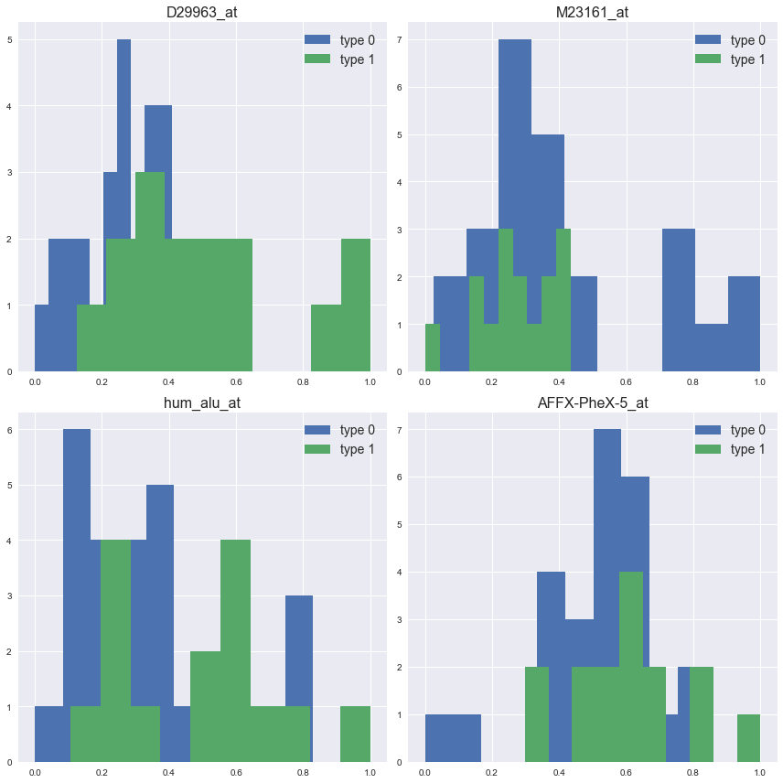

```python
type0 = data_train_normalized.loc[(data_train_normalized['Cancer_type'] == 0.0)]
type1 = data_train_normalized.loc[(data_train_normalized['Cancer_type'] == 1.0)]

fig, axes = plt.subplots(nrows=2, ncols=2, figsize=(12,12))
ax0, ax1, ax2, ax3 = axes.flatten()

ax0.hist(type0['D29963_at'], label='type 0')
ax0.hist(type1['D29963_at'], label='type 1')
ax0.legend(prop={'size': 14})
ax0.set_title('D29963_at', fontsize=16)

ax1.hist(type0['M23161_at'], label='type 0')
ax1.hist(type1['M23161_at'], label='type 1')
ax1.legend(prop={'size': 14})
ax1.set_title('M23161_at',fontsize=16)

ax2.hist(type0['hum_alu_at'], label='type 0')
ax2.hist(type1['hum_alu_at'], label='type 1')
ax2.legend(prop={'size': 14})
ax2.set_title('hum_alu_at',fontsize=16)

ax3.hist(type0['AFFX-PheX-5_at'], label='type 0')
ax3.hist(type1['AFFX-PheX-5_at'], label='type 1')
ax3.legend(prop={'size': 14})
ax3.set_title('AFFX-PheX-5_at',fontsize=16)

fig.tight_layout()
plt.show()
```

One way to tell if any of these four genes discriminate between the two classes well would be to look at the histograms and see if there is a clear deviation between the distribution of type 0 and type 1. Looking at the graphs above, this does not seem to be the case. None of them are discriminating between the two classes well. For example, looking at the D29963_at gene, there is overlap between type 0 and type 1's expression distribution, therefore it cannot be said that D29963 discriminates. Same with the other three genes.

**1.5:** Since our data has dimensions that are not easily visualizable, we want to reduce the dimensionality of the data to make it easier to visualize. Using PCA, find the top two principal components for the gene expression data. Generate a scatter plot using these principal components, highlighting the two cancer types in different colors. How well do the top two principal components discriminate between the two classes? How much of the variance within the data do these two principal components explain?

```
% of variance within data that these components explain: 27.317829452185432
```

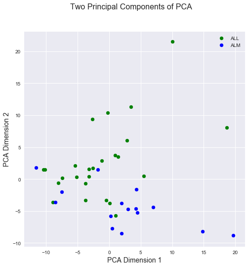

```python
y_train = data_train_normalized['Cancer_type']

x_train = data_train_normalized[data_train_normalized.columns[data_train_normalized.columns!='Cancer_type'] ]

pca_transformer = PCA(2).fit(x_train)
x_train_2d = pca_transformer.transform(x_train)

colors = ['g', 'b']
label_text=['ALL', 'ALM']

fig, axe = plt.subplots(figsize=(8,8))
for cancer_type in [0,1]:
    cur_df = x_train_2d[y_train==cancer_type]
    plt.scatter(cur_df[:,0], cur_df[:,1], c = colors[cancer_type], label=label_text[cancer_type])
plt.suptitle('Two Principal Components of PCA', fontsize=16);
plt.xlabel('PCA Dimension 1', fontsize=14)
plt.ylabel('PCA Dimension 2',fontsize=14)
plt.legend();


print('% of variance within data that these components explain:', 100*sum(pca_transformer.explained_variance_ratio_))
```

These top two principal compononents do not discriminate between the two classes very well. As we can see from the graph above, there is a lot of overlap between the two classes, so it is hard to discriminate between the two classes. If they were discriminated well, there would be clear seperation between the two colors.

The top two principal components explain about 27.31% of the variance within the training data set.

## Question 2: Linear Regression vs. Logistic Regression

In class we discussed how to use both linear regression and logistic regression for classification. For this question, you will work with a single gene predictor, `D29963_at`, to explore these two methods.

1. Fit a simple linear regression model to the training set using the single gene predictor `D29963_at`. We could interpret the scores predicted by the regression model interpreted for a patient as an estimate of the probability that the patient has `Cancer_type`=1. Is there a problem with this interpretation?
2. The fitted linear regression model can be converted to a classification model (i.e. a model that predicts one of two binary labels 0 or 1) by classifying patients with predicted score greater than 0.5 into `Cancer_type`=1, and the others into the `Cancer_type`=0. Evaluate the classification accuracy (1 - misclassification rate) of the obtained classification model on both the training and test sets.
3. Next, fit a simple logistic regression model to the training set. How do the training and test classification accuracies of this model compare with the linear regression model? Remember, you need to set the regularization parameter for sklearn's logistic regression function to be a very large value in order to not regularize (use 'C=100000').
4. Plot the quantitative output from the linear regression model and the probabilistic output from the logistic regression model (on the training set points) as a function of the gene predictor. Also, display the true binary response for the training set points in the same plot. Based on these plots, does one of the models appear better suited for binary classification than the other? Explain.

#### Answers:

**2.1:** Fit a simple linear regression model to the training set using the single gene predictor `D29963_at`. We could interpret the scores predicted by the regression model interpreted for a patient as an estimate of the probability that the patient has `Cancer_type`=1. Is there a problem with this interpretation?

```python
train_x = data_train_normalized['D29963_at']
y_train = data_train_normalized['Cancer_type']

train_x = train_x.values.reshape(-1,1)

linreg = LinearRegression()

OLSModel = linreg.fit(train_x, y_train)
```

Yes, there is a problem with this interpretation. In this part of the question, we are using a linear regressision model and the question asks if we can predict using the results of linear regression. The answer to that is no. Since linear regression only fits a linear line to the data, we cannot predict from it. We need a probability between 0 and 1 to do this and linear regression cannot do that. Logistic regression is the one that keeps all of its values between 0 and 1 and does exactly what is needed; outputting an estimate of the probability.

**2.2:** The fitted linear regression model can be converted to a classification model (i.e. a model that predicts one of two binary labels 0 or 1) by classifying patients with predicted score greater than 0.5 into `Cancer_type`=1, and the others into the `Cancer_type`=0. Evaluate the classification accuracy (1 - misclassification rate) of the obtained classification model on both the training and test sets.

```python
# normalize using same scale as training set
data_test_normalized = pd.DataFrame(train_scaled.transform(data_test), columns=data_test.columns)

y_test = data_test_normalized['Cancer_type']
x_test = data_test_normalized['D29963_at']
x_test = x_test.values.reshape(-1,1)

print('Classification Accuracy from LineReg')
print('---------')
score = accuracy_score(y_train, OLSModel.predict(train_x).round(), normalize=True)
print('Training set:', score)
print('Misclassification Rate:', 1-score)
score2 = accuracy_score(y_test, OLSModel.predict(x_test).round(), normalize=True)
print('---------')
print('Test set:', score2)
print('Misclassification Rate:', 1-score2)
```

```
Classification Accuracy from LineReg
---------
Training set: 0.8
Misclassification Rate: 0.19999999999999996
---------
Test set: 0.7575757575757576
Misclassification Rate: 0.24242424242424243
```

**2.3:** Next, fit a simple logistic regression model to the training set. How do the training and test classification accuracies of this model compare with the linear regression model? Remember, you need to set the regularization parameter for sklearn's logistic regression function to be a very large value in order to not regularize (use 'C=100000').

```python
logit = LogisticRegression(C=1000000)
logit.fit(train_x, y_train)

print('Classification Accuracy from LogReg')
print('---------')
score3 = accuracy_score(y_train, logit.predict(train_x).round(), normalize=True)
print('Training set:', score3)
print('Misclassification Rate:', 1-score3)
print('---------')
score4 = accuracy_score(y_test, logit.predict(x_test), normalize=True)
print('Training set:', score4)
print('Misclassification Rate:', 1-score4)
```

```
Classification Accuracy from LogReg
---------
Training set: 0.8
Misclassification Rate: 0.19999999999999996
---------
Training set: 0.7575757575757576
Misclassification Rate: 0.24242424242424243
```

Comparing the classification accuracies from 2.2 (linereg) to 2.3 (logreg), there is no difference. Using two different methods, we were able to get the same classification and misclassification rates for both the training and test set.

**2.4:** Plot the quantitative output from the linear regression model and the probabilistic output from the logistic regression model (on the training set points) as a function of the gene predictor. Also, display the true binary response for the training set points in the same plot. Based on these plots, does one of the models appear better suited for binary classification than the other? Explain.

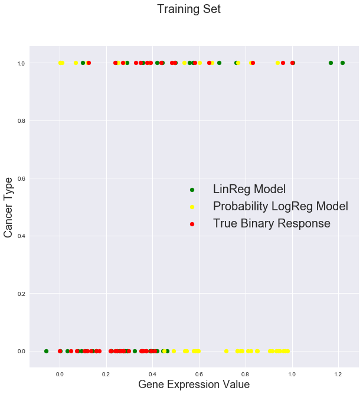

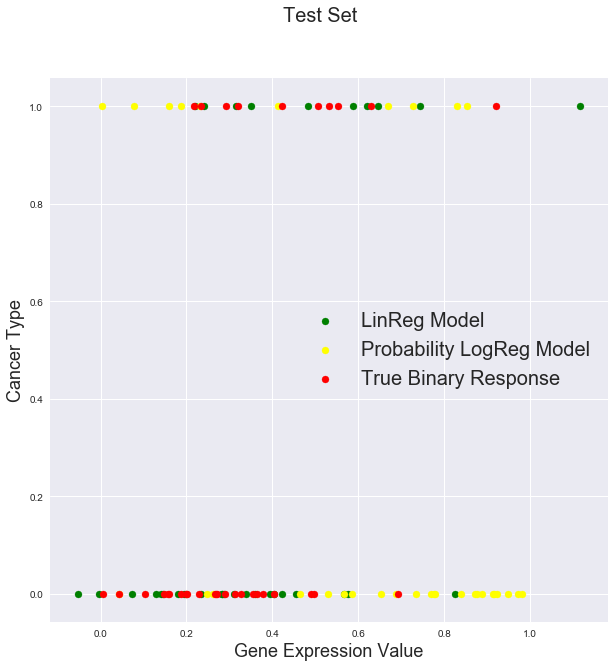

```python
label_text = ['LinReg Model', 'Probability LogReg Model', 'True Binary Response']

fig, ax1 = plt.subplots(figsize=(10,10))
# quantitive output from linreg model
plt.scatter(OLSModel.predict(train_x), y_train, color='green', label=label_text[0])
# probability output from logreg model
plt.scatter(logit.predict_proba(train_x)[:,0], y_train, color='yellow', label=label_text[1])
#true binary response from training set points
plt.scatter(train_x, y_train, color='red' , label=label_text[2])
fig.suptitle('Training Set', fontsize=20);
plt.xlabel('Gene Expression Value', fontsize=18)
plt.ylabel('Cancer Type', fontsize=18)
plt.legend(fontsize=20)
plt.show()

fig, ax1 = plt.subplots(figsize=(10,10))
plt.scatter(OLSModel.predict(x_test), y_test, color='green', label=label_text[0])
plt.scatter(logit.predict_proba(x_test)[:,0], y_test, color='yellow' , label=label_text[1])
plt.scatter(x_test, y_test, color='red', label=label_text[2])
fig.suptitle('Test Set', fontsize=20);
plt.xlabel('Gene Expression Value', fontsize=18)
plt.ylabel('Cancer Type', fontsize=18)
plt.legend(fontsize=20)
plt.show()
```

In 2.3, we calcualted the scores and saw that both logreg and linreg produced identical classification rates. However, as said in 2.1, data from linear regression does not allow us to make binary predictions, whereas logistical regression allows us to do exactly that; therefore (conceptually) logreg is the model better suited for binary classification.

However, if we look at the graphs above, it looks like the linear regression model is better suited for binary classification because the green (linreg) and red (true binary response) points tend to overlap with each other, whereas the yellow (logreg) doesn't. The same thing can be said for the training set graph where the green (linreg) and red (true binary response) points tend to overlap also.

So if we need at the graphs, linear regression model is a good model for binary classification, but conceptually, logreg is better suited because it outputs a probability.

## Question 3: Multiple Logistic Regression

1. Next, fit a multiple logistic regression model with all the gene predictors from the data set. How does the classification accuracy of this model compare with the models fitted in question 2 with a single gene (on both the training and test sets)?
2. Use the `visualize_prob` function provided below to visualize the probabilties predicted by the fitted multiple logistic regression model on both the training and test data sets. The function creates a visualization that places the data points on a vertical line based on the predicted probabilities, with the different cancer classes shown in different colors, and with the 0.5 threshold highlighted using a dotted horizontal line. Is there a difference in the spread of probabilities in the training and test plots? Are there data points for which the predicted probability is close to 0.5? If so, what can you say about these points?

```python
#--------  visualize_prob
# A function to visualize the probabilities predicted by a Logistic Regression model
# Input:
#      model (Logistic regression model)
#      x (n x d array of predictors in training data)
#      y (n x 1 array of response variable vals in training data: 0 or 1)
#      ax (an axis object to generate the plot)

def visualize_prob(model, x, y, ax):
    # Use the model to predict probabilities for
    y_pred = model.predict_proba(x)

    # Separate the predictions on the label 1 and label 0 points
    ypos = y_pred[y==1]
    yneg = y_pred[y==0]

    # Count the number of label 1 and label 0 points
    npos = ypos.shape[0]
    nneg = yneg.shape[0]

    # Plot the probabilities on a vertical line at x = 0,
    # with the positive points in blue and negative points in red
    pos_handle = ax.plot(np.zeros((npos,1)), ypos[:,1], 'bo', label = 'Cancer Type 1')
    neg_handle = ax.plot(np.zeros((nneg,1)), yneg[:,1], 'ro', label = 'Cancer Type 0')

    # Line to mark prob 0.5
    ax.axhline(y = 0.5, color = 'k', linestyle = '--')

    # Add y-label and legend, do not display x-axis, set y-axis limit
    ax.set_ylabel('Probability of AML class')
    ax.legend(loc = 'best')
    ax.get_xaxis().set_visible(False)
    ax.set_ylim([0,1])
```

#### Answers

**3.1:** Next, fit a multiple logistic regression model with all the gene predictors from the data set. How does the classification accuracy of this model compare with the models fitted in question 2 with a single gene (on both the training and test sets)?

```python
logit1 = LogisticRegression(C=1000000)
logit1.fit(x_train, y_train)

y_test = data_test_normalized['Cancer_type']
test_x = data_test_normalized.drop(['Cancer_type'], axis = 1)

print('Classification Accuracy from Multiple LogReg')
print('---------')
score5 = accuracy_score(y_train, logit1.predict(x_train).round(), normalize=True)
print('Training set:', score5)
print('Misclassification Rate:', 1-score5)
print('---------')
score6 = accuracy_score(y_test, logit1.predict(test_x).round(), normalize=True)
print('Test set:', score6)
print('Misclassification Rate:', 1-score6)
```

```
Classification Accuracy from Multiple LogReg
---------
Training set: 1.0
Misclassification Rate: 0.0
---------
Test set: 1.0
Misclassification Rate: 0.0
```

**3.2:** Use the `visualize_prob` function provided below to visualize the probabilties predicted by the fitted multiple logistic regression model on both the training and test data sets. The function creates a visualization that places the data points on a vertical line based on the predicted probabilities, with the different cancer classes shown in different colors, and with the 0.5 threshold highlighted using a dotted horizontal line. Is there a difference in the spread of probabilities in the training and test plots? Are there data points for which the predicted probability is close to 0.5? If so, what can you say about these points?

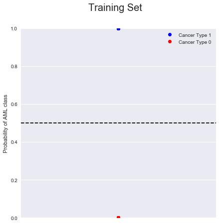

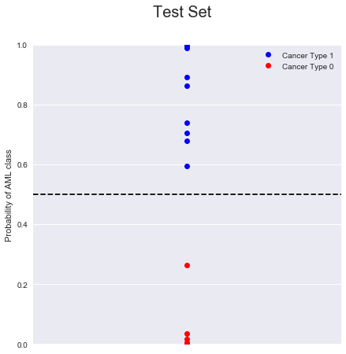

```python
fig, ax = plt.subplots(figsize=(7,7))
visualize_prob(logit1, x_train, y_train, ax)
fig.suptitle('Training Set', fontsize=20);


fig, ax = plt.subplots(figsize=(7,7))
visualize_prob(logit1, test_x, y_test, ax)
fig.suptitle('Test Set', fontsize=20);
```

## Question 4: Analyzing Significance of Coefficients

How many of the coefficients estimated by the multiple logistic regression in the previous problem are significantly different from zero at a *significance level of 95%*?

Hint: To answer this question, use *bootstrapping* with 1000 boostrap samples/iterations.

#### Answer:

```python
def make_bootstrap_sample(dataset_X, dataset_y, size = None):

    # your code here

    # by default return a bootstrap sample of the same size as the original dataset
    if not size: size = len(dataset_X)

    # if the X and y datasets aren't the same size, raise an exception
    if len(dataset_X) != len(dataset_y):
        raise Exception("Data size must match between dataset_X and dataset_y")


    sample_indices = np.random.choice(size, size=size, replace=True)

    bootstrap_dataset_X = dataset_X.iloc[sample_indices, :]
    bootstrap_dataset_y = dataset_y[sample_indices]

    # return as a tuple your bootstrap samples of dataset_X as a pandas dataframe
    # and your bootstrap samples of dataset y as a numpy column vector

    return (bootstrap_dataset_X, bootstrap_dataset_y)


def calculate_coefficients(dataset_X, dataset_y, model):

    # your code here

    # fit the model
    model.fit(dataset_X, dataset_y)

    coefficients_dictionary = dict(zip(dataset_X.columns, model.coef_.ravel()))

    # return coefficients  in the variable  coefficients_dictioanry as a dictionary
    # with the key being the name of the feature as a string
    # the value being the value of the coefficients
    # do not return the intercept as part of this
    return coefficients_dictionary


def get_significant_predictors(regression_coefficients, significance_level):

    # your code here


    # regression_coefficients is a list of dictionaries
    # with the key being the name of the feature as a string
    # the value being the value of the coefficients
    # each dictionary in th list should be the output of calculate_coefficients

    if (len(regression_coefficients) <= 0):
        return []

    coeff_names = np.array(list(regression_coefficients[0].keys()), dtype='object')
    coeff_samples = [list(coeff_list.values()) for coeff_list in regression_coefficients]

    coeff_samples = np.array(coeff_samples)

    # Obtain bottom percentile values
    bottom_percentile = np.percentile(coeff_samples, q=significance_level/2, axis=0)

    # Obtain top percentile values
    top_percentile = np.percentile(coeff_samples, q=1-significance_level/2, axis=0)

    # Coefficients with bottom value greater than 0 or top value less than 0 are signficant
    significant_index = ((bottom_percentile > 0.0) | (top_percentile < 0.0))

    significant_coefficients = list(coeff_names[significant_index])

    # return the significant coefficients as a list of strings
    return significant_coefficients
```

```python
N_bootstrap_samples = 1000
regression_coefficients = []
for i in range(N_bootstrap_samples):
    sample = make_bootstrap_sample(x_train, y_train)
    coefficient_dict = calculate_coefficients(sample[0], sample[1], LogisticRegression(C=1000000))
    regression_coefficients.append(coefficient_dict)

print(len(get_significant_predictors(regression_coefficients, 0.05)))
```

```
1929
```

Around 1929 coeffs estimated by mulitple logisitic regresstion are signfiicantly different from zero.

## Question 5: High Dimensionality

One of the issues you may run into when dealing with high dimensional data is that your 2D and 3D intuition may fail breakdown. For example, distance metrics in high dimensions can have properties that may feel counterintuitive.

Consider the following: You have a hypersphere with a radius of $1$, inside of a hypercube centered at $0$, with edges of length $2$.

1. As a function of $d$, the number of dimensions, how much of the hypercube's volume is contained within the hypersphere?
2. What happens as $d$ gets very large?
3. Using the functions provided below, create a plot of how the volume ratio changes as a function of $d$.
4. What does this tell you about where the majority of the volume of the hypercube resides in higher dimensions?

*HINTS:*

- The volume of a hypercube with edges of length $2$ is $V_c(d) = 2^d$.
- The volume of a hyperphere with a radius of $1$ is $V_s(d) = \frac{\pi^{\frac{d}{2}}} {\Gamma(\frac{d}{2}+1)}$, where $\Gamma$ is Euler's Gamma Function.
- $\Gamma$ is increasing for all $d \geq 1$.

```python
def V_c(d):
    """
    Calculate the volumn of a hypercube of dimension d.
    """
    return 2**d

def V_s(d):
    """
    Calculate the volume of a hypersphere of dimension d.
    """
    return math.pi**(d/2)/gamma((d/2)+1)
```

#### Answers:

1.

$V_c(d) / $V_(d) = $(2^d$) / $\frac{\pi^{\frac{d}{2}}} {\Gamma(\frac{d}{2}+1)}$

The expression above is shown as a function of d.

2.

As d gets very large, the ratio of the hypercube volume:hypersphere volume goes towards infinitiy.

3.

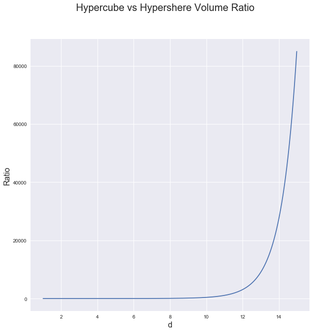

```python
d = np.arange(1, 15, .01)

fig, ax1 = plt.subplots(figsize=(10,10))
ax1.plot(d, V_c(d)/(V_s(d)))
ax1.set_xlabel('d', fontsize=16)
ax1.set_ylabel('Ratio', fontsize=16)
fig.suptitle('Hypercube vs Hypershere Volume Ratio', fontsize=20);
```

4.

If radius is smaller than edges of length, the hypersphere is fully inside the hypercube. They are equal. If the radius is larger than the edges of length, it is the opposite, hypercube is completely inside the hypersphere.

resource: https://math.stackexchange.com/questions/1996000/intersection-of-hypercube-and-hypersphere

## Question 6: PCA and Dimensionality Reduction

As we saw above, high dimensional problems can have counterintuitive behavior, thus we often want to try to reduce the dimensionality of our problems. A reasonable approach to reduce the dimensionality of the data is to use PCA and fit a logistic regression model on the smallest set of principal components that explain at least 90% of the variance in the predictors.

1. Using the gene data from Problem 1, how many principal components do we need to capture at least 90% of the variance? How much of the variance do they actually capture? Fit a Logistic Regression model using these principal components. How do the classification accuracy values on both the training and tests sets compare with the models fit in question 3.1?
2. Use the code provided in question 3 to visualize the probabilities predicted by the fitted model on both the training and test sets. How does the spread of probabilities in these plots compare to those for the model in question 3.2? If the lower dimensional representation yields comparable predictive power, what advantage does the lower dimensional representation provide?

#### Answers:

**6.1:** Using the gene data from Problem 1, how many principal components do we need to capture at least 90% of the variance? How much of the variance do they actually capture? Fit a Logistic Regression model using these principal components. How do the classification accuracy values on both the training and tests sets compare with the models fit in question 3.1?

```python
pca = PCA(n_components=0.90).fit(x_train)
x_train_2 = pca.transform(x_train)

print('Principal Componenents Needed for 90% Variance:', pca.n_components_)
print('Variance percentage actually captured (%):', 100*sum(pca.explained_variance_ratio_))

print('---------')
print('---------')

logit2 = LogisticRegression(C=1000000)
logit2.fit(x_train_2, y_train)

print('Classification Accuracy from LogReg after PCA')
print('---------')

score7 = accuracy_score(y_train, logit2.predict(x_train_2))
print('Training set:', score7)
print('Misclassification Rate:', 1-score7)
print('---------')

x_test_2 = pca.transform(test_x)
score8 = accuracy_score(y_test, logit2.predict(x_test_2))
print('Test set:', score8)
print('Misclassification Rate:', 1-score8)
```

```
Principal Componenents Needed for 90% Variance: 29
Variance percentage actually captured (%): 90.26870362661793
---------
---------
Classification Accuracy from LogReg after PCA
---------
Training set: 1.0
Misclassification Rate: 0.0
---------
Test set: 0.9696969696969697
Misclassification Rate: 0.030303030303030276
```

Compared to 3.1, the classification accuracy for the training set is identical at 1.0. For the test set, they are nearly identical. 3.1 outputted 1.0, whereas the test set in 6.1 outputted 0.97, so they are nearly the same. There is a small chance for miscalculations from the model in 6.1, as shown as the miscalculation rate of 0.0303.

**6.2:** Use the code provided in question 3 to visualize the probabilities predicted by the fitted model on both the training and test sets. How does the spread of probabilities in these plots compare to those for the model in question 3.2? If the lower dimensional representation yields comparable predictive power, what advantage does the lower dimensional representation provide?

[figure not shown]

[figure not shown]

```python
fig, ax = plt.subplots(figsize=(7,7))
visualize_prob(logit2, x_train_2d, y_train, ax)
fig.suptitle('Training Set', fontsize=20);

fig, ax = plt.subplots(figsize=(7,7))
visualize_prob(logit2, x_test_2d, y_test, ax)
fig.suptitle('Test Set', fontsize=20);
```

One advantage that a lower dimentional representation provides is that it allows the computer to compute the data quicker(and use less space) because there are less dimensions (predictors) to crunch the data on. This reduces the number of random variables under consideration, makes the data easier to visualize, and the removal of the multi-colinearly improves the performance of the model itself.

resource used: https://en.wikipedia.org/wiki/Dimensionality_reduction#Advantages_of_dimensionality_reduction

## Multiclass Thyroid Classification

In this problem, you will build a model for diagnosing disorders in a patient's thyroid gland. Given the results of medical tests on a patient, the task is to classify the patient either as:

- *normal* (class 1)
- having *hyperthyroidism* (class 2)
- or having *hypothyroidism* (class 3).

The data set is provided in the file `dataset_hw5_2.csv`. Columns 1-2 contain biomarkers for a patient (predictors):

- Biomarker 1: (Logarithm of) level of basal thyroid-stimulating hormone (TSH) as measured by radioimmuno assay
- Biomarker 2: (Logarithm of) maximal absolute difference of TSH value after injection of 200 micro grams of thyrotropin-releasing hormone as compared to the basal value.

The last column contains the diagnosis for the patient from a medical expert. This data set was obtained from the UCI Machine Learning Repository.

Notice that unlike previous exercises, the task at hand is a 3-class classification problem. We will explore the use of different methods for multiclass classification.

First task: split the data using the code provided below.

## Question 7: Fit Classification Models

1. Generate a 2D scatter plot of the training set, denoting each class with a different color. Does it appear that the data points can be separated well by a linear classifier?
2. Briefly explain the difference between multinomial logistic regression and one-vs-rest (OvR) logistic regression methods for fitting a multiclass classifier (in 2-3 sentences).
3. Fit linear classification models on the thyroid data set using both the methods. You should use $L_2$ regularization in both cases, tuning the regularization parameter using cross-validation. Is there a difference in the overall classification accuracy of the two methods on the test set?
4. Also, compare the training and test accuracies of these models with the following classification methods:
   - Multiclass Logistic Regression with quadratic terms
   - Linear Discriminant Analysis
   - Quadratic Discriminant Analysis
   - k-Nearest Neighbors  
     *Note:* you may use either the OvR or multinomial variant for the multiclass logistic regression (with $L_2$ regularization). Do not forget to use cross-validation to choose the regularization parameter, and also the number of neighbors in k-NN.
5. Does the inclusion of the polynomial terms in logistic regression yield better test accuracy compared to the model with only linear terms?

*Hint:* You may use the `KNeighborsClassifier` class to fit a k-NN classification model.